# 1. Setup

## 1.2 Set up Matrix with Site Info

```r
#### MANUALLY Identify which siteID you want to use:
site <- "WBC"
```

Now let’s get ready to make an EGRET object. For ease of quickly reusing this Rmd for different sites, a matrix with the site info has been created. The final chunk indexes the matrix by the site abbreviation entered in the first code chunk above and saves the corresponding info for setting up the EGRET object. No start/end dates are provided in the matrix because EGRET automatically will add start/end dates from the record the stream gage discharge data if none are provided. This will keep the data as current as possible each time the code is run.

## 1.3 Set up EGRET object

*OPTIONAL*: If you only want figures with data that is only USGS approved, the `dplyr::filter` will remove any of the provisional data. ALSO, the arguments within the function `setPA()` can be altered to display a particular season or time period of interest. Currently, `paStart` is set to 10, meaning the record starts in October, and `paLong` is set to 12, meaning that the record will include all 12 months following water year conventions. These values could be changed to 1 and 12 respectively if you want the calendar year summaries (January to December), or 3 and 4 respectively if you wanted March through June, and so on.

[output not shown]

```
##
## Flow Duration for WBC
##
## Flow duration is based on full year
##
## Discharge units are Cubic Feet per Second
```

# 2. Historical Flow

## 2.1 Historical Flow Percentiles

The historical percentiles of daily discharge are provided in CFS first to get an idea of the general distribution of the data.

Historical Flow Percentiles for Wet Beaver Creek near Rimrock, AZ

|  | Discharge (cfs) |
| --- | --- |
| min | 4.20 |
| 5% | 6.00 |
| 10% | 6.28 |
| 25% | 6.70 |
| 50% | 7.30 |
| 75% | 8.20 |
| 90% | 44.00 |
| 95% | 130.00 |
| max | 5230.00 |

## 2.2 Historical Flow Hydrograph

The below hydrograph displays the the mean and median from the entire record.

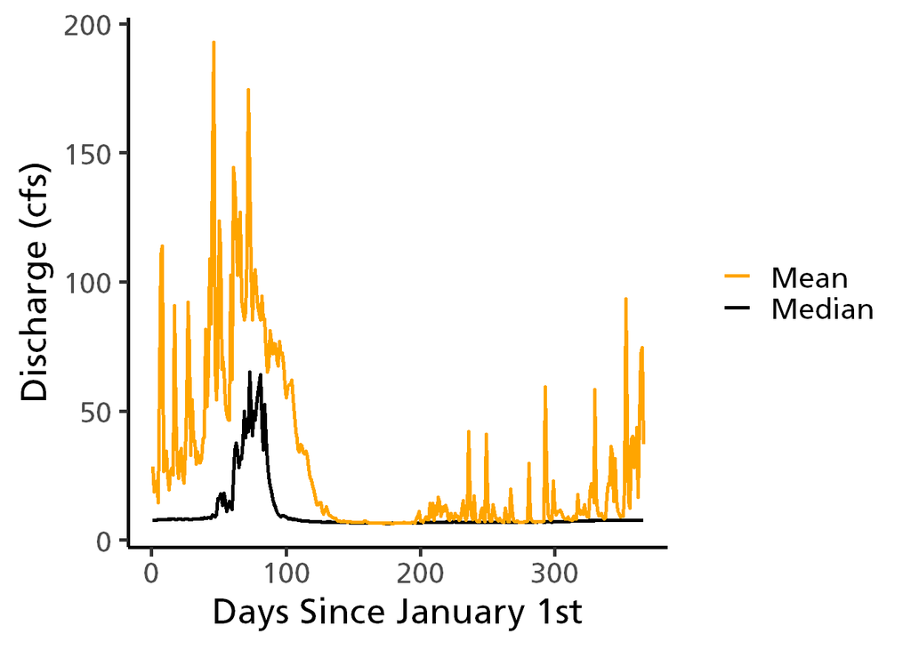

Annual hydrographs (annual discharge sum) for both the calendar year and water year.

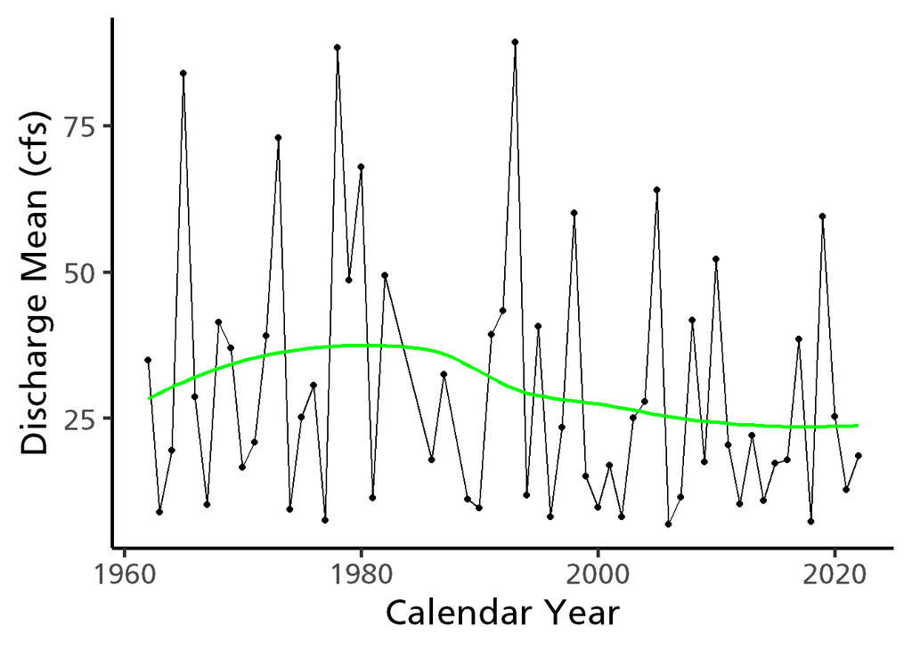

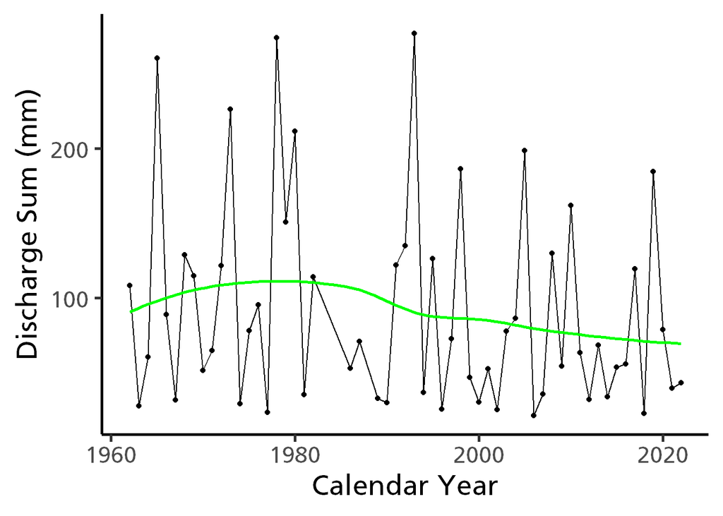

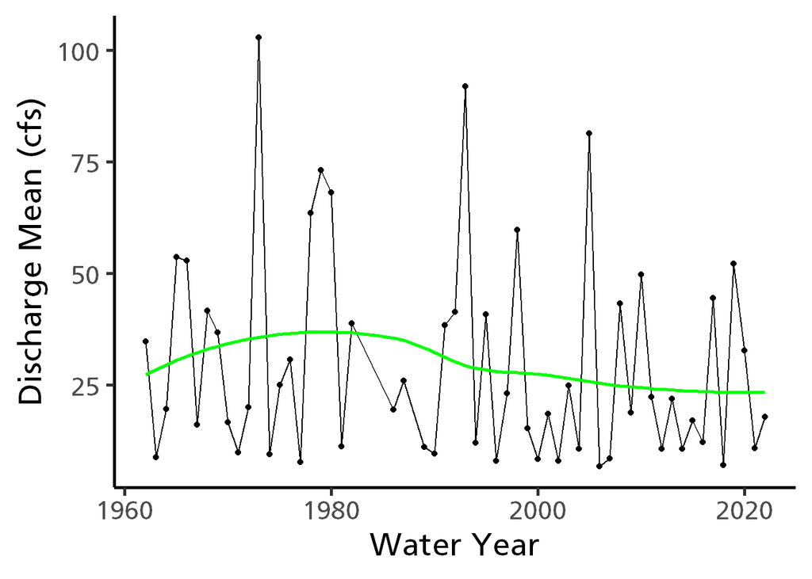

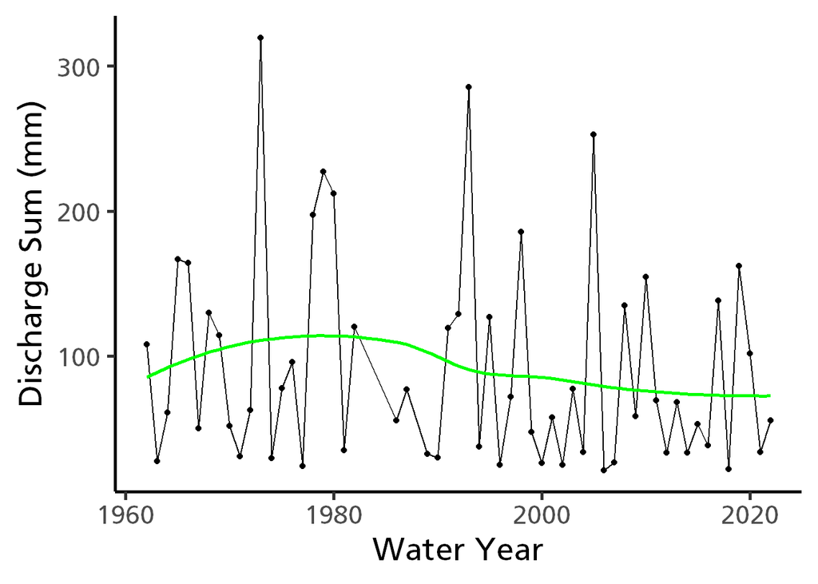

## 2.3 Flow Duration Curves

The flow duration curve (FDC) is shown below. According to the USGS, the shape of the curves reveal information about the watershed. Steep slopes throughout indicate high stream variability impacted primarily by runoff, while flatter slopes generally indicate that the flow is equalized by storage in surface water or groundwater (Searcy, 1959). Flat slopes at low flow end and high flow ends of the FDC also are informative about the stream characteristics. If the stream stores a lot of water, flat slopes at the low flow end are expected. If the slope is flat at the high end, this generally indicates flow from snowmelt, flood plains, or swamp drainage (Searcy, 1959).

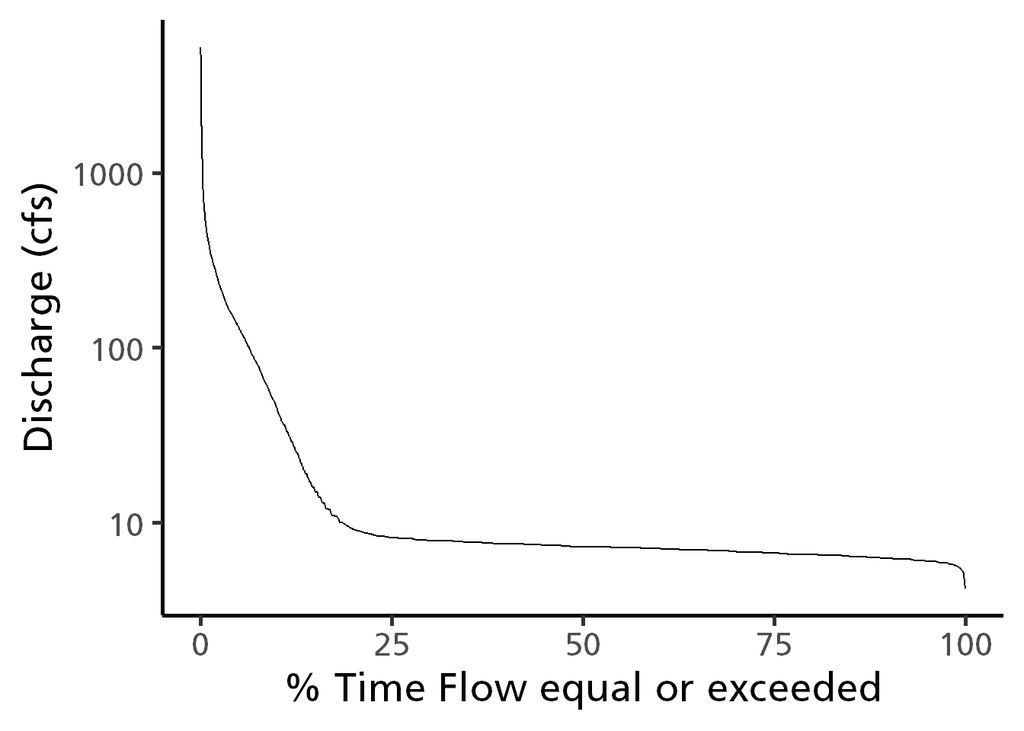

# 3. EGRET Discharge Plots for Water Year (October 1st - September 30th)

## 3.1 Plot Four Function Note

The EGRET `plotFourStats()` code was modified so that it will plot the results for any 4 of the 8 discharge stats options in EGRET (denoted istats). The new function is called `plotFourAny(eList, istat1, istat2, istat3, istat4)`. The user must specify the 4 istat numbers that they want when using this function. The other arguments default to the defaults for `plotFourStats()`. The code can be viewed in the Rmd version of this script.

## 3.2 EGRET Discharge Plots

The data will now be plotted to examine possible long term trends in discharge! The EGRET function `plotFourStats()` and a modified version of that function, `plotFourAny()` will be used so that all 8 available discharge stats can be displayed (Table 2). According to the EGRET documentation (Hirsch & De Cicco, 2015), these statistics are calculated based on the first day provided for `paStart` and go through every day until the the last day of `paLong` months from the start. So, if you told EGRET you wanted the period March-June, the statistics are returned for this time period. **Please note, according to the EGRET documentation,** there is an exception for the water year statistics. All of the minimums (i.e. 1-day minimum) for the water year plots are noted in EGRET to be calculated using climate year (April 1-March 31) to minimize droughts spanning multiple water years.

Available EGRET istats.

| discharge_stat | Discharge Statistic Name |
| --- | --- |
| 1 | Minimum 1-day |
| 2 | Minimum 7-day mean |
| 3 | Minimum 30-day mean |
| 4 | Median |
| 5 | Mean |
| 6 | Maximum 30-day mean |
| 7 | Maximum 7-day mean |
| 8 | Maximum 1-day |

Summarized from the EGRET documentation (Hirsch & De Cicco, 2015):

The lines shown in these plots are computed using locally weighted scatter plot smoothing (lowess) for time-series. This approaches smooths out the time series data (annual) so trends can be visualized at longer time spans (more than a decade). The trend lines resist the presence of a few extremes, but the user should take caution, as this means that sudden changes in a stream may be smoothed away. To quickly summarize what is occurring during the smoothing process: the annual discharge statistics are transformed to a log-scale (ln). This deals with right skewness, often present in discharge data, as extremes tend to be from high flows. Weighted regressions are performed for each year’s discharge statistics. The weight applied to each discharge value in each regression depends on the year – for example, if the regression is being performed for 2001 mean discharge, the 2001 mean discharge has the highest weight, and the weights applied to discharges within a 20 year window decay as they get further in time away. Those outside the window have no weight. The windows are by default widened for the ends of the record, because there is more data available on one side of the end values than the other side. The discharge is then re-transformed back from the log scale, resulting in the smooth trend lines. The technique is usually ideal for a total record length of 50+ years, but can also be applied to shorter records.

This first plot shows, for the water year Oct.-Sept., the maximum daily discharge, mean daily discharge, median daily discharge, and 7-day minimum daily discharge.

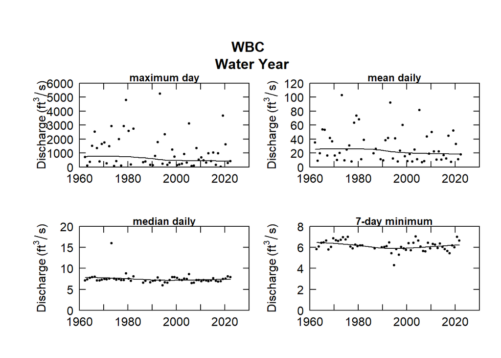

The next four plots show the remaining flow statistic trend lines: minimum day, 30-day maximum, 30-day minimum, and 7-day maximum. Recall that the minimums are determined by the Climate Year.

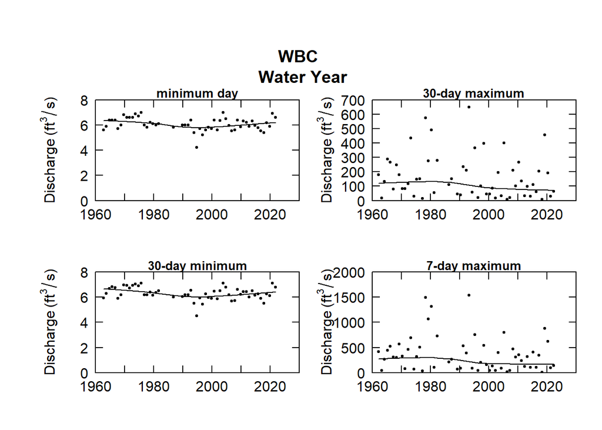

## 3.3 Flow Statistics with Mann-Kendall Test

The code for this is sourced in the flowTrends.R file in Section 1.1 and was copied from the EGRET page on USGS via [this site](https://rconnect.usgs.gov/EGRET/articles/streamflow_trend.html#making-a-graph-of-the-trend-in-a-single-flow-statistic) (Hirsch, R.M., 2018 (updated 2023), Daily Streamflow Trend Analysis).

These graphs use the same smoothing method as the plots described in section 2 for the same discharge statistics, but the smoothing window is 30 years (rather than 20 years as in the functions from Section 3.2). Therefore, for short time periods (~30 years) a lot of the trend lines will look like straight lines or very smooth curves. The plot also gives a trend slope (calculated by Theil-Sen Estimator, linear for univariate time-series) in % per year with a p-value estimate based on Mann-Kendall, adjusted for year to year serial correlation (common in time-series).

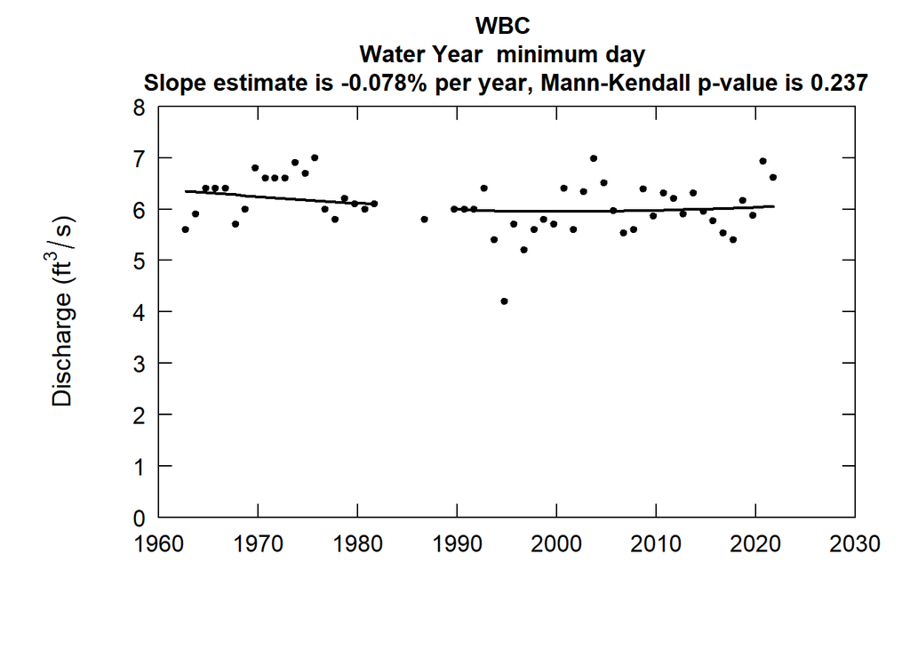

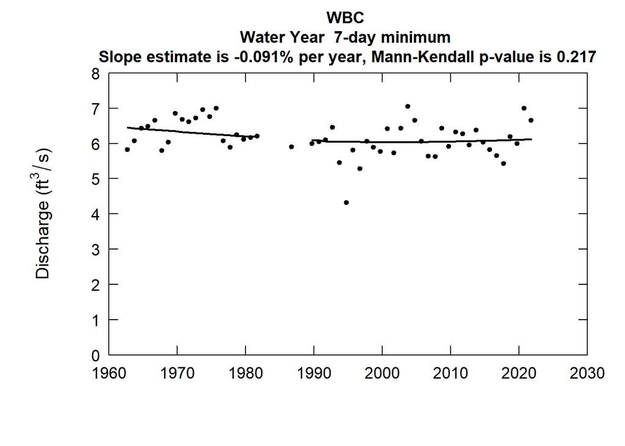

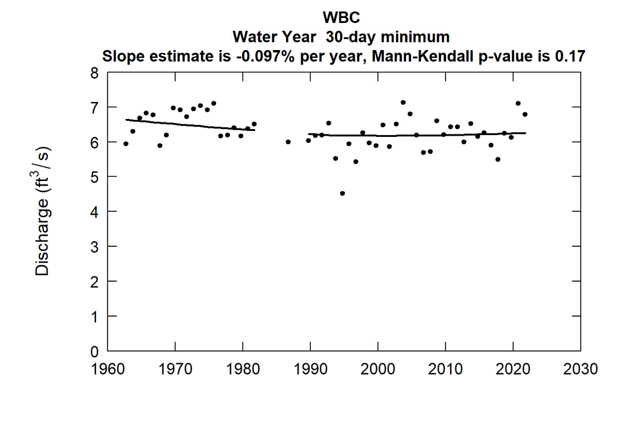

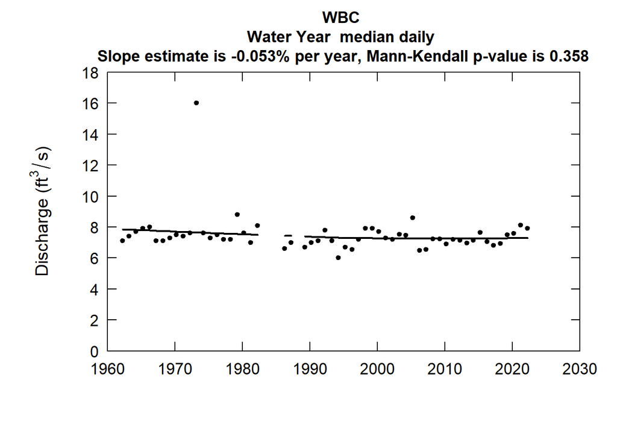

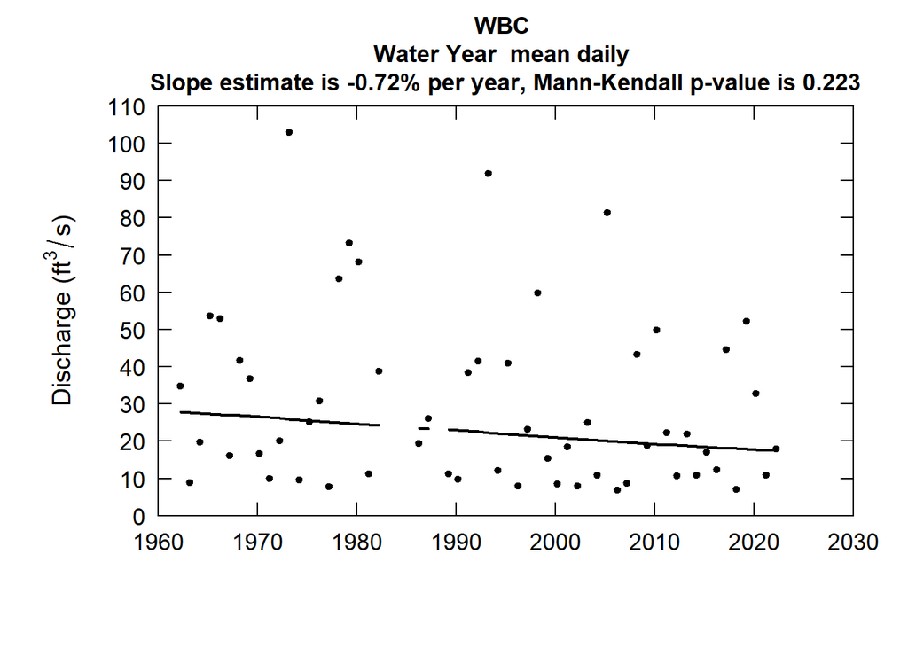

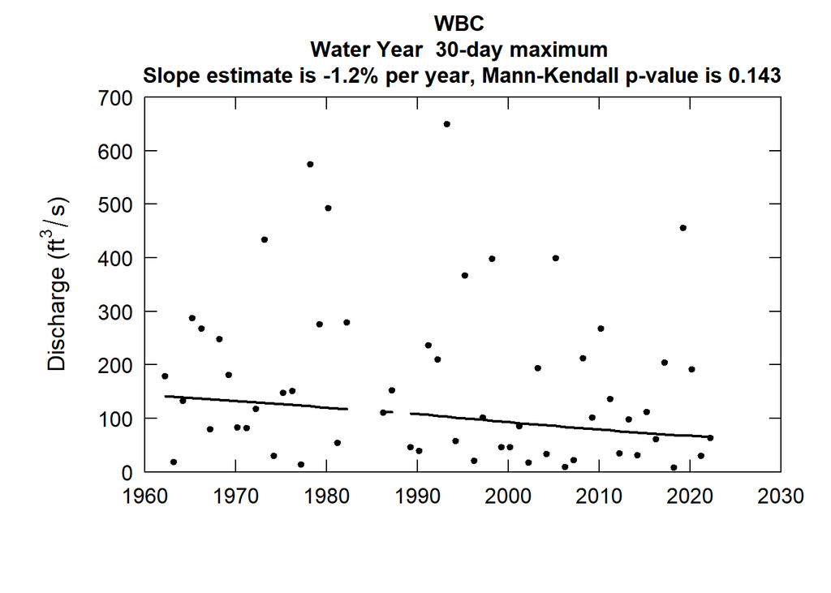

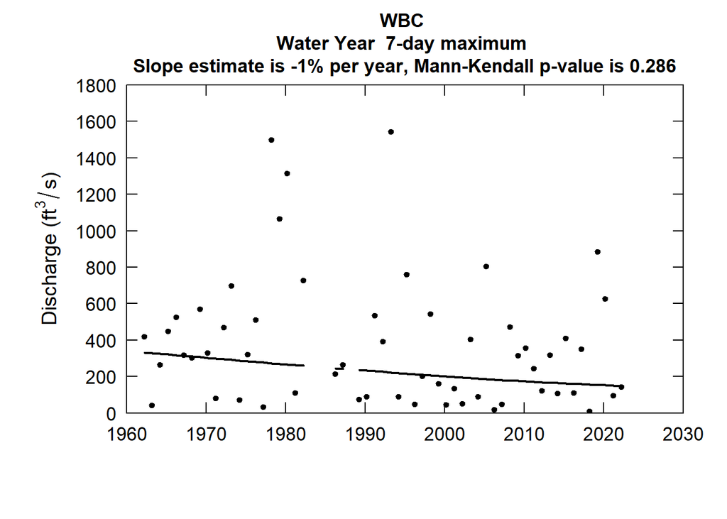

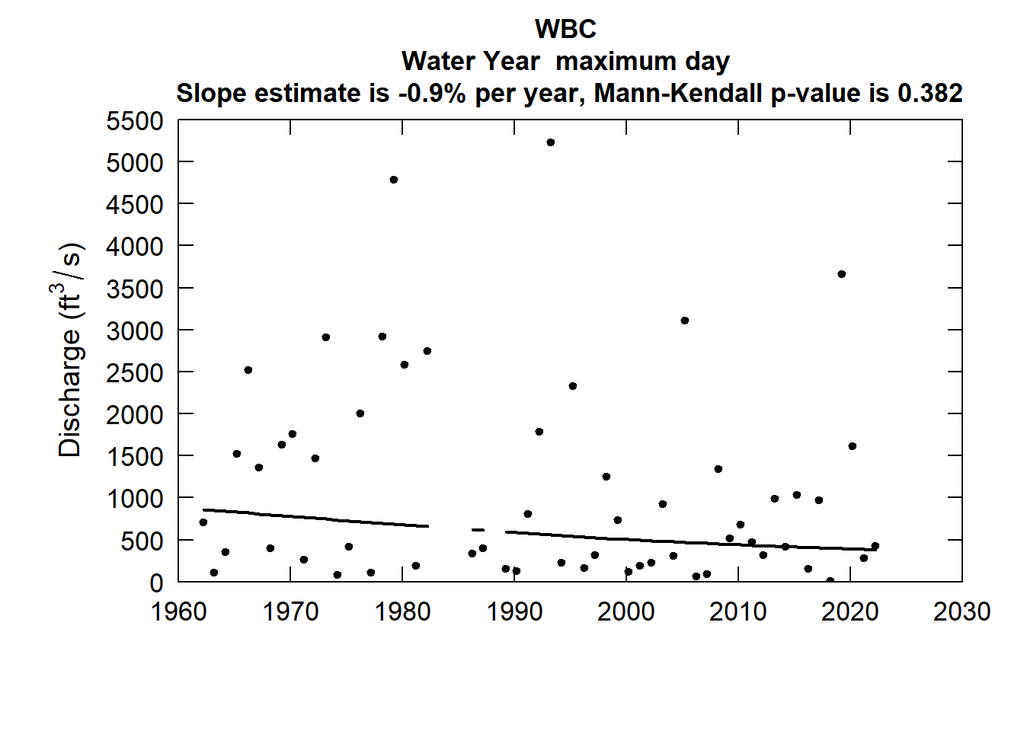

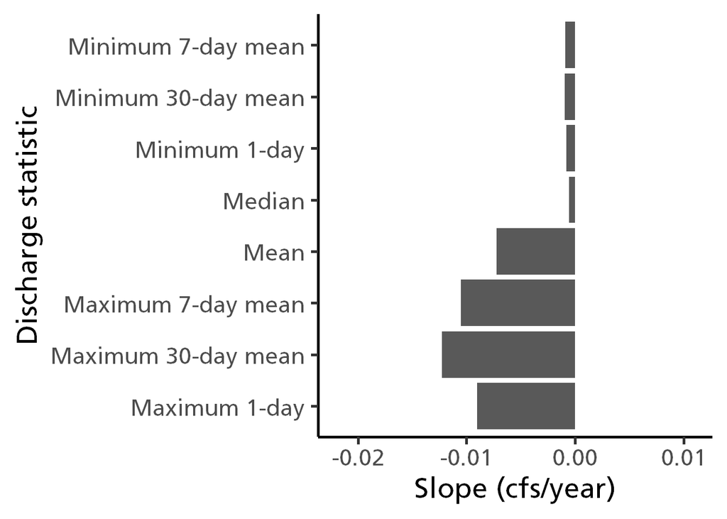

## 3.4 Standard Deviation Plot of the Daily Mean (Log)

This plot helps to assess the variability of the data set over time (Hirsch & De Cicco, 2015). It takes the standard deviation of the log of the annual mean daily discharge (Q), resulting in a dimensionless statistic. This is useful information for observing potential trends in variability over time. For example, if the result of plotting the standard deviation over time is an upward trending curve, this suggests that there is more change in the high or low end of the distribution than the middle. The results may inform whether changing conditions are changing flow variability, such as more extreme precipitation events combined with more periods of prolonged heat/drought from a changing climate. The default window is 15 years.

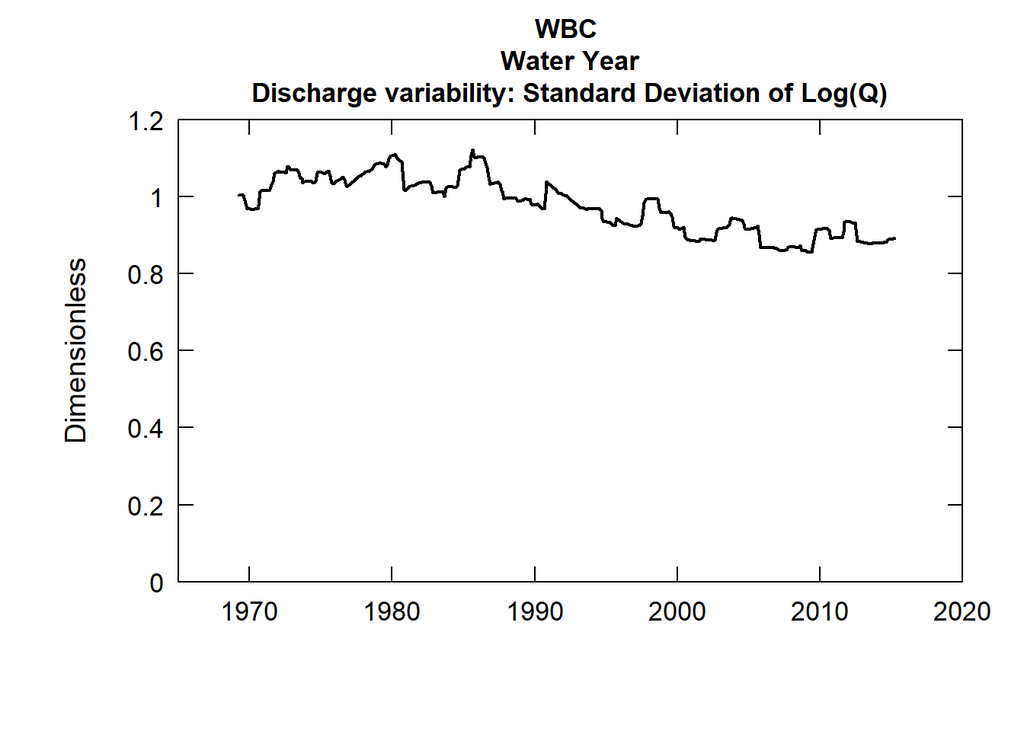

## 3.5 Seasonal Plots

These figures divide the data into the four seasons, and then visualize the lowess for each one separately for 7-day minimum, Mean, and 1-day maximum. There are a lot plots, but these can help diagnose if there are seasonal trends in any of the discharge statistics that are not apparent in the annual plots (Hirsch & De Cicco, 2015). If any show trends of note, further analyses can be conducted on the particular season of interest.

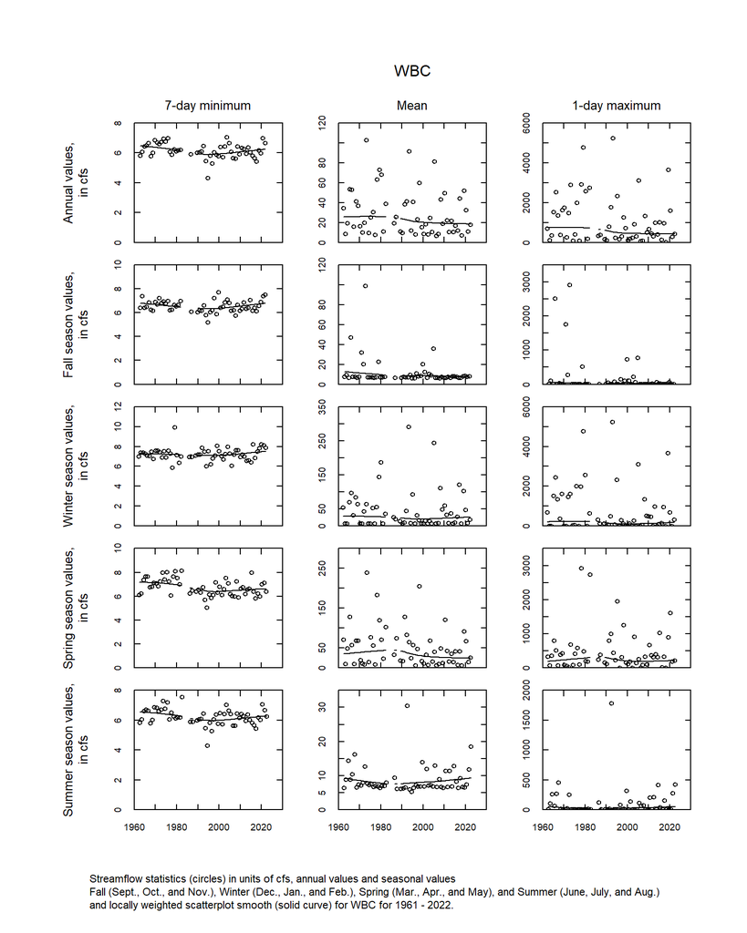

## 3.6 Quantile-Kendall results

The following graph is a Quantile-Kendall plot. This graph visualizes both the trend slope AND the p-value for each flow quantile (ranging from the annual minimum and all the way to the annual maximum). Therefore, it shows the slope and p-value for a range of percentiles (from minimum to maximum, a total of 365 order statistics, i.e. 365 points on the plot), in one figure. The y-axis provides the trend estimate (the percent change positive or negative per year) and the color of each point gives the Mann-Kendall p-value.

A table with the p-values less than 0.1 is also provided below the Quantile-Kendall plot so that the exact slope, p-value, and change over the record can be reported.

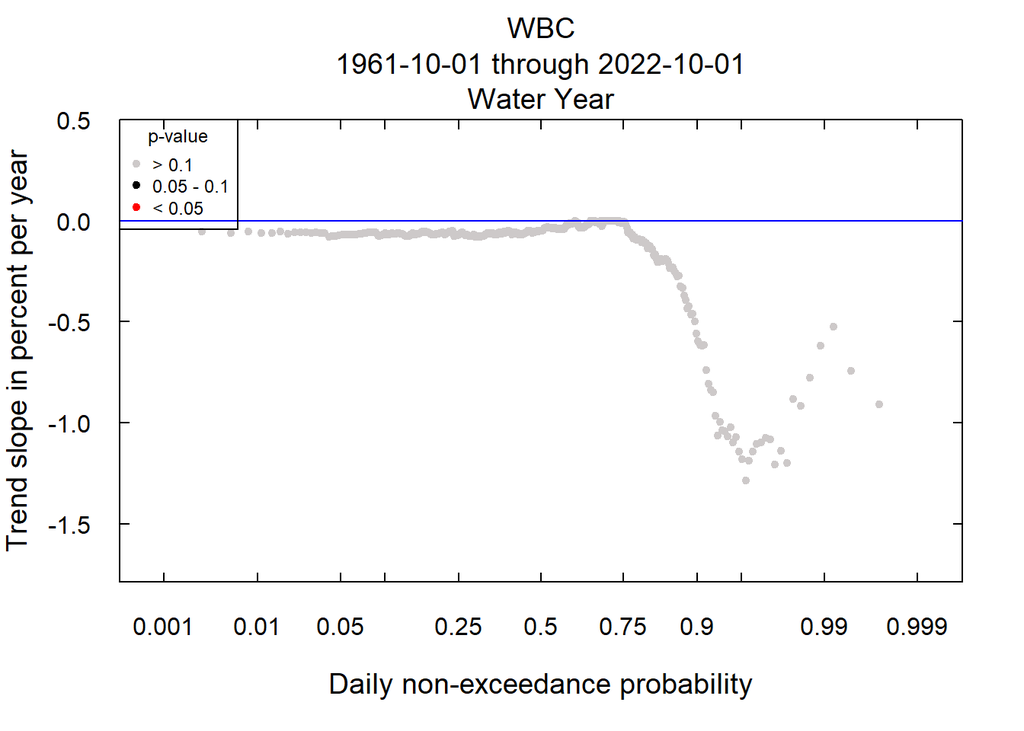

```
## [1] "No p-values < 0.1"
```

# 4. EGRET Daily Discharge Plots

## 4.1 Daily Discharge Plots

These plots show the daily discharge over the complete discharge record. This can be a helpful way to visualize possible trends over time in daily discharge (Hirsch & De Cicco, 2015).

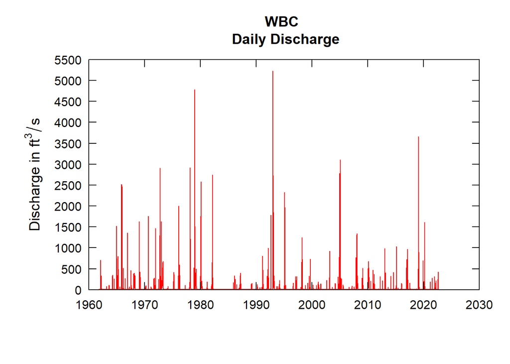

## 4.2 Daily Discharge Over the 95th Percentile

Next, the same type of plot is shown, but only with discharge values above the 95th percentile. Recall above in Section 1 that the EGRET `flowDuration()` function was run and to calculate the historical flow at various percentiles. This function at default provides the discharge at multiple percentiles for the whole year, which can then be indexed. In this case, the 8th result of the vector `flow_percentiles[8]` will serve as the 95th percentile and the lower bound on the discharge. Daily discharge above the 95th percentile can then be displayed and examined for potential trends (Hirsch & De Cicco, 2015).

*OPTIONAL*: If there are other lower bounds you are interested in, the value of qLower can be adjusted.

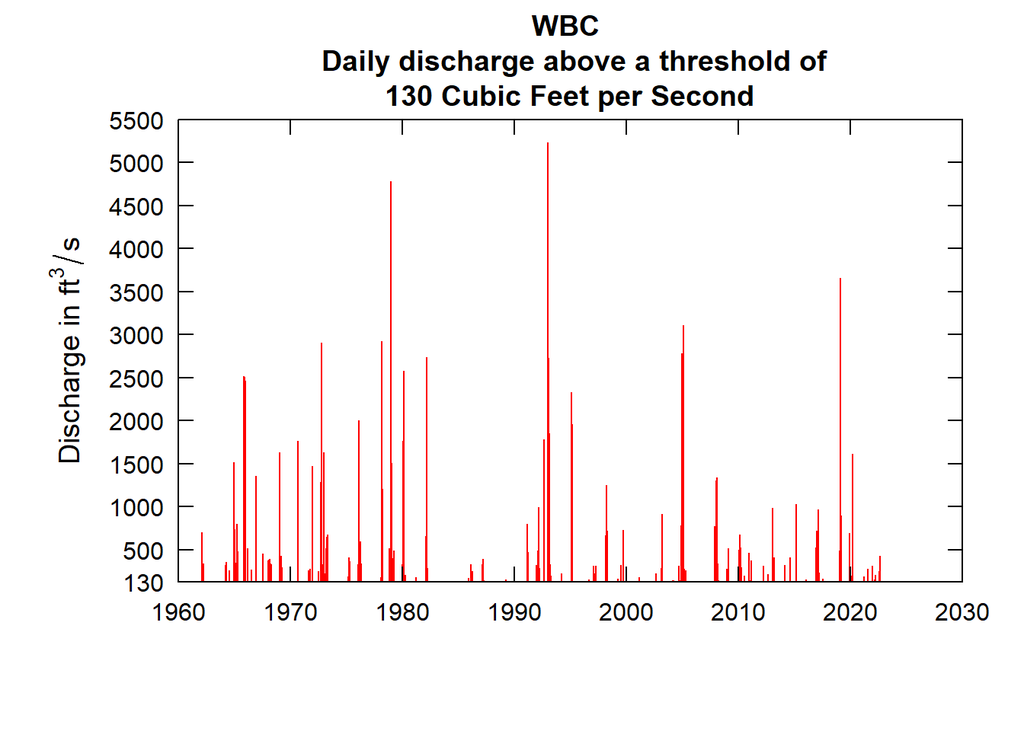

# 5. Peak Flow Plots

## 5.1 Peak Flow Trend Plot: Theil-Sen Median Line vs. Ordinary Least Squares Regression

Both the Theil-Sen line and ordinary least squares (OLS) regression are visualized. The function for this plot was adapted and modified from Chapter 10.1 of *Statistical Methods in Water Resources* (Helsel et al., 2020). OLS regression is one of the most commonly used linear models. However, it is extremely susceptible to outliers, which can influence the slope and significance test for OLS. OLS also assumes residuals are distributed normally. Violations to OLS assumptions may occur in discharge records. In the plot below, the data should generally behave well, since dates are being regressed rather than discharge measurements, but it is possible there may be an influential point or two from years that had exceptionally wet or dry conditions. Theil-Sen still assumes that there is a linear relationship present, but is nonparametric. It is a model of the median. It therefore does not make assumptions about the distribution and is less sensitive to outliers, while still assuming a linear relationship. The presence of a linear relationship should be verified by visually examining the scatter plots before reporting significance tests.

This analysis can help determine whether there is a linear trend in the peak flow over the record. For example, if the slope appears positive, the date of peak flow is on average getting later each year, while a negative slope would indicate that the date of peak flow is getting earlier each year.

In cases where the assumptions for OLS regression are met, OLS is slightly more efficient (lower root mean square error) than Theil-Sen. Theil-Sen is far superior when these aren’t met (Helsel et al., 2020). Assuming a linear relationship, the Theil-Sen slope and significance test should be reported if there are major questions about whether the assumptions for OLS regression are met, especially if the trend lines appear to vary quite a bit between the two models.

```
##
##       Theil-Sen line
##
## Days Since October 1st = -833.75 + 0.5 * Water Year
##
##        95 % Confidence interval on the slope
## LCL =  -0.373  Theil slope =  0.5  UCL =  1.711
##
```

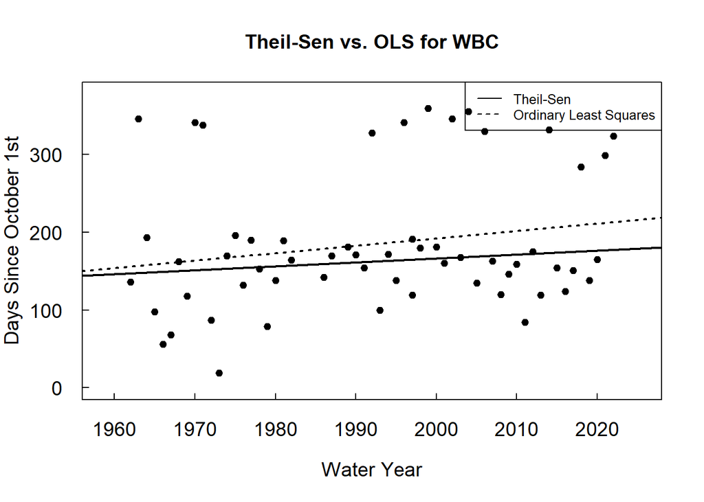

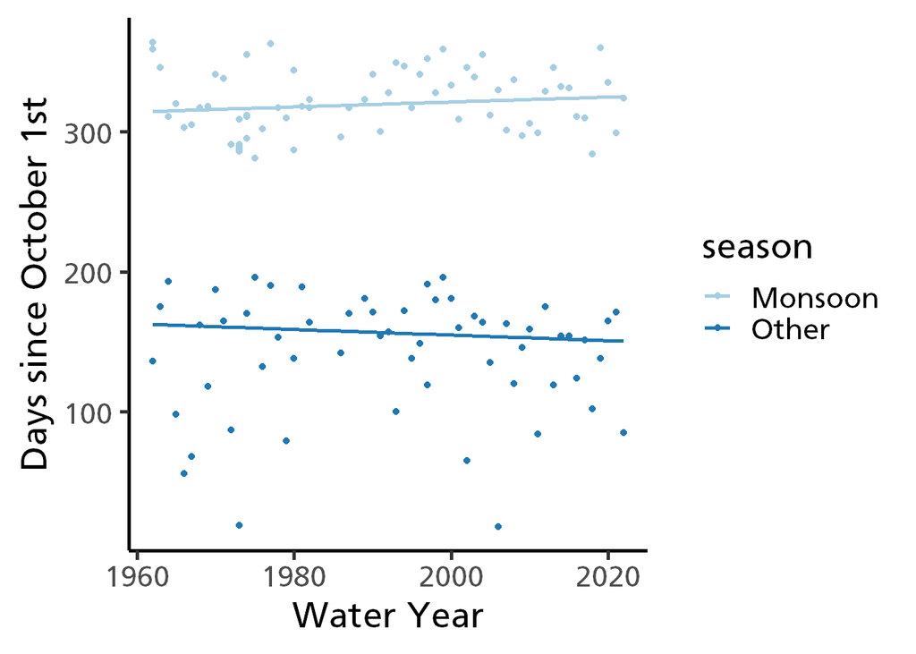

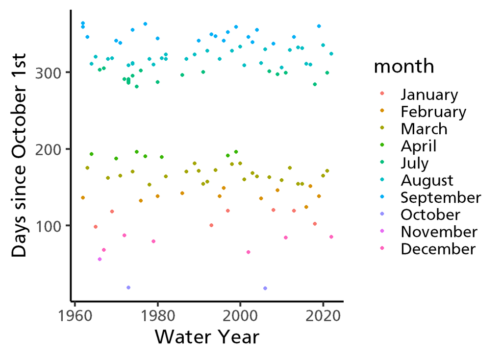

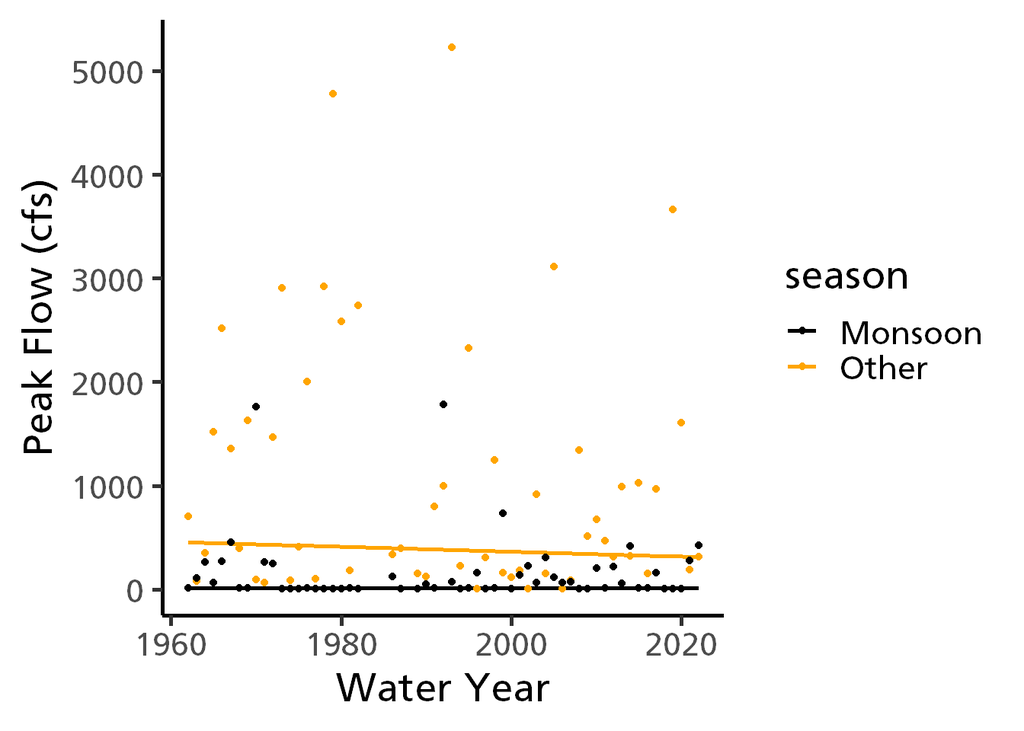

Theil-Sen P-value, Coefficients, and Confidence Interval Limits for Wet Beaver Creek near Rimrock, AZ

| P-value | Slope | Estimated Change per Century (number of days) | Intercept | Lower Confidence Limit | Upper Confidence Limit |
| --- | --- | --- | --- | --- | --- |
| 0.271 | 0.5 | 50 | -833.75 | -0.373 | 1.711 |

## 5.2 Ordinary Least Squares Regression

```
##
## Call:
## lm(formula = peakflow$wateryear_day ~ peakflow$waterYear)
##
## Residuals:
##     Min      1Q  Median      3Q     Max
## -147.34  -56.67  -23.41   25.77  189.20
##
## Coefficients:
##                      Estimate Std. Error t value Pr(>|t|)
## (Intercept)        -1716.3935  1265.6673  -1.356    0.181
## peakflow$waterYear     0.9543     0.6352   1.502    0.139
##
## Residual standard error: 86.87 on 56 degrees of freedom
## Multiple R-squared:  0.03874,    Adjusted R-squared:  0.02158
## F-statistic: 2.257 on 1 and 56 DF,  p-value: 0.1386
```

# 6. References

## 6.1 Packages

1. R: R Core Team (2021). R: A language and environment for statistical computing. R Foundation for Statistical Computing, Vienna, Austria. URL https://www.R-project.org/.
2. dataRetrieval: De Cicco, L.A., Hirsch, R.M., Lorenz, D., Watkins, W.D., Johnson, M., 2022, dataRetrieval: R packages for discovering and retrieving water data available from Federal hydrologic web services, v.2.7.12, doi:10.5066/P9X4L3GE.
3. EGRET: Hirsch, R.M., De Cicco, L.A., Murphy, J., 2023, Exploration and Graphics for RivEr Trends (EGRET), version 3.0.9, doi:10.5066/P9CC9JEX.
4. Tidyverse: Wickham H, Averick M, Bryan J, Chang W, McGowan LD, François R, Grolemund G, Hayes A, Henry L, Hester J, Kuhn M, Pedersen TL, Miller E, Bache SM, Müller K, Ooms J, Robinson D, Seidel DP, Spinu V, Takahashi K, Vaughan D, Wilke C, Woo K, Yutani H (2019). “Welcome to the tidyverse.” _Journal of Open Source Software_, *4*(43), 1686. doi: 10.21105/joss.01686 (URL: [https://doi.org/10.21105/joss.01686).](https://doi.org/10.21105/joss.01686).).
5. rkt: Aldo Marchetto (2021). rkt: Mann-Kendall Test, Seasonal and Regional Kendall Tests. R package version 1.6. https://CRAN.R-project.org/package=rkt.
6. zyp: David Bronaugh and Arelia Schoeneberg (2023). zyp: Zhang + Yue-Pilon Trends Package. R package version 0.11-1. https://CRAN.R-project.org/package=zyp.
7. lubridate: Garrett Grolemund, Hadley Wickham (2011). Dates and Times Made Easy with lubridate. Journal of Statistical Software, 40(3), 1-25. URL https://www.jstatsoft.org/v40/i03/..
8. kableExtra: Hao Zhu (2021). kableExtra: Construct Complex Table with ‘kable’ and Pipe Syntax. R package version 1.3.4. https://CRAN.R-project.org/package=kableExtra.
9. scales: Hadley Wickham and Dana Seidel (2022). scales: Scale Functions for Visualization. R package version 1.2.1. https://CRAN.R-project.org/package=scales.

## 6.2 Literature References

1. Cade, B.S. and Noon, B.R., 2003. A gentle introduction to quantile regression for ecologists. *Frontiers in Ecology and the Environment*, *1*(8), pp.412-420.
2. Gannon, J.P, 9-Flow-Duration-Curves, 2021, Github repository, https://github.com/VT-Hydroinformatics/9-Flow-Duration-Curves.git.
3. Helsel, D.R., Hirsch, R.M., Ryberg, K.R., Archfield, S.A., and Gilroy, E.J., 2020, Statistical methods in water resources: U.S. Geological Survey Techniques and Methods, book 4, chap. A3, 458 p., https://doi.org/10.3133/tm4a3. [Supersedes USGS Techniques of Water-Resources Investigations, book 4, chap. A3, version 1.1.].
4. Hirsch, R.M., and De Cicco, L.A., 2015, User guide to Exploration and Graphics for RivEr Trends (EGRET) and dataRetrieval—R packages for hydrologic data (version 2.0, February 2015): U.S. Geological Survey Techniques and Methods book 4, chap. A10, 93 p., http://dx.doi.org/10.3133/tm4A10.
5. Hirsch, R.M., 2018 (updated 2023), Daily Streamflow Trend Analysis https://waterdata.usgs.gov/blog/quantile-kendall/.
6. Hirsch, R.M., Moyer, D.L., and Archfield, S.A., 2010, Weighted Regressions on Time, Discharge, and Season (WRTDS), with an application to Chesapeake Bay River inputs: Journal of the American Water Resources Association, v. 46, no. 5, p. 857–880, http://onlinelibrary.wiley.com/doi/10.1111/j.1752-1688.2010.00482.x/full.
7. Searcy, J.K., 1959, Flow-duration curves: Water Supply Paper 1542A, accessed at http://pubs.er.usgs.gov/publication/wsp1542A.

# 7. Supplemental Information

## 7.1 Discharge Distributions

Below shows the historical distribution of the daily discharge data, and the corresponding empirical cumulative distribution function. This code was adapted from a Hydroinformatics repository (Gannon, 2021). The red lines show the median of the daily discharge data from the full record.

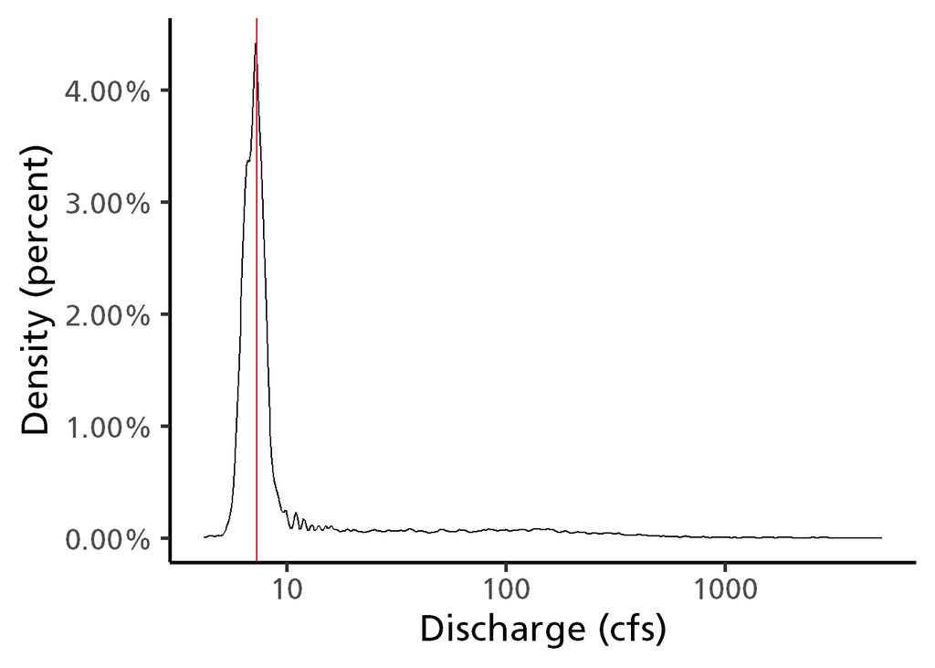

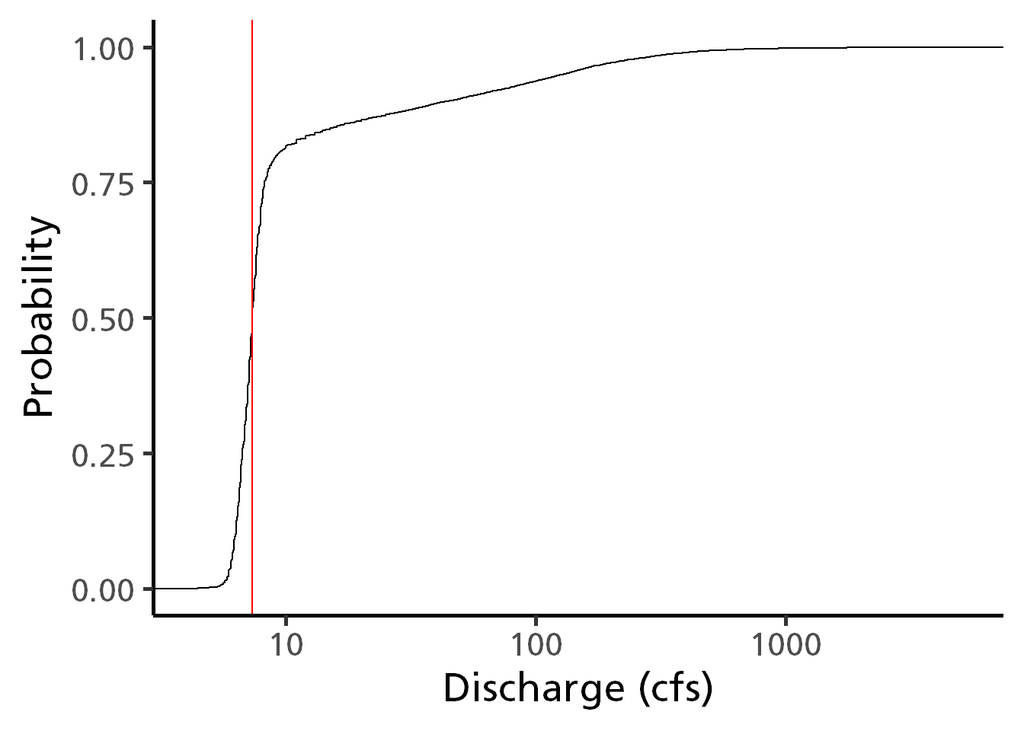

## 7.2 Saving Data from this Rmd as CSVs

Note, to convert this entire Rmd to a plain old R script the following commands can be run by supplying the file path to this Rmd file on your local device:

```r
library(knitr)
rmd_file <- "/Users/abigailvolk/Documents/NPS_SIP/Flow_Analysis/Flow_analysis.Rmd"
knitr::purl(rmd_file)
```